# R Notebook

```r
library(tidyverse)
library(janitor)
library(broom)
library(factoextra)
```

# Task 1: Do some exploratory analysis on the data. Comment on findings.

```r
mall_customers <- read_csv("data/mall_customers.csv") %>%
  clean_names()
```

```r
skimr::skim(mall_customers)
```

```
── Data Summary ────────────────────────
                           Values
Name                       mall_customers
Number of rows             200
Number of columns          5
_______________________
Column type frequency:
  character                1
  numeric                  4
________________________
Group variables            None
```

|  | skim_variable | n_missing | complete_rate | min | max | empty | n_unique | whitespace |
| --- | --- | --- | --- | --- | --- | --- | --- | --- |
| 1 | gender | 0 | 1 | 4 | 6 | 0 | 2 | 0 |

|  | skim_variable | n_missing | complete_rate | mean | sd | p0 | p25 | p50 | p75 | p100 | hist |
| --- | --- | --- | --- | --- | --- | --- | --- | --- | --- | --- | --- |
| 1 | customer_id | 0 | 1 | 100.50 | 57.87918 | 1 | 50.75 | 100.5 | 150.25 | 200 | ▇▇▇▇▇ |
| 2 | age | 0 | 1 | 38.85 | 13.96901 | 18 | 28.75 | 36.0 | 49.00 | 70 | ▆▇▅▃▂ |
| 3 | annual_income_k | 0 | 1 | 60.56 | 26.26472 | 15 | 41.50 | 61.5 | 78.00 | 137 | ▆▇▇▂▁ |
| 4 | spending_score_1_100 | 0 | 1 | 50.20 | 25.82352 | 1 | 34.75 | 50.0 | 73.00 | 99 | ▃▃▇▃▃ |

```r
summary(mall_customers)
```

```
  customer_id        gender               age        annual_income_k  spending_score_1_100
 Min.   :  1.00   Length:200         Min.   :18.00   Min.   : 15.00   Min.   : 1.00
 1st Qu.: 50.75   Class :character   1st Qu.:28.75   1st Qu.: 41.50   1st Qu.:34.75
 Median :100.50   Mode  :character   Median :36.00   Median : 61.50   Median :50.00
 Mean   :100.50                      Mean   :38.85   Mean   : 60.56   Mean   :50.20
 3rd Qu.:150.25                      3rd Qu.:49.00   3rd Qu.: 78.00   3rd Qu.:73.00
 Max.   :200.00                      Max.   :70.00   Max.   :137.00   Max.   :99.00
```

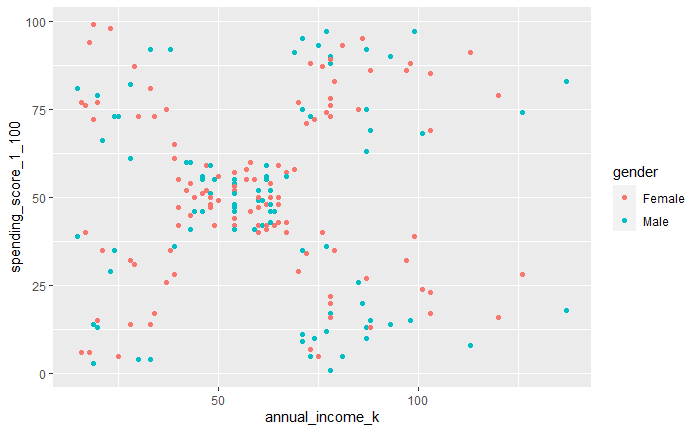

```r
mall_customers %>%
  ggplot(aes(x = annual_income_k, y = spending_score_1_100, colour = gender))+
  geom_point()
```

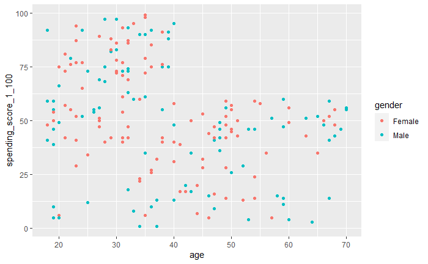

```r
mall_customers %>%
  ggplot(aes(x = age, y = spending_score_1_100, colour = gender))+
  geom_point()
```

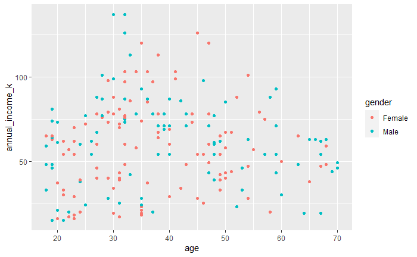

```r
mall_customers %>%
  ggplot(aes(x = age, y = annual_income_k, colour = gender))+
  geom_point()
```

From the graph correlating spending score with annual income, it looks initially like there are 5 groups, 4 arranged around a central group.

Looks like there are group of incomes arranged in a line at £54k and £78k, could be a default income?

Age and gender seem to be fairly evenly distributed, no discernable patter to these variables.

The age vs spending_score is interesting as the lower ages are spending the highest amounts, whereas older age groups have lower spending scores.

# Task 2: We are interested in creating a marketing campaign to target customers based on their spending score and annual income. Select an appropriate value for k and perform k-means clustering to find if there are meaningful clusters in the data to target the customer

```r
mall_cust_scaled <- mall_customers %>%
  select(annual_income_k, spending_score_1_100) %>%
  mutate(across(everything(),
         .fns = scale))
```

```r
min_k <- 2
max_k <- 10

k_clusters <- tibble(k = min_k:max_k) %>%
  mutate(kclust = map(k, ~kmeans(mall_cust_scaled, centers = .x, nstart = 25)),
         tidied = map(kclust, tidy),
         glance = map(kclust, glance),
         augmented = map(kclust, augment, mall_customers))

k_clusters
```

| k | kclust | tidied | glance | augmented |
| --- | --- | --- | --- | --- |
| 2 |  |  |  |  |
| 3 |  |  |  |  |
| 4 |  |  |  |  |
| 5 |  |  |  |  |
| 6 |  |  |  |  |
| 7 |  |  |  |  |
| 8 |  |  |  |  |
| 9 |  |  |  |  |
| 10 |  |  |  |  |

```r
clusterings <- k_clusters %>%
  unnest(glance)

clusterings
```

| k | kclust | tidied | totss | tot.withinss | betweenss | iter | augmented |
| --- | --- | --- | --- | --- | --- | --- | --- |
| 2 |  |  | 398 | 267.67171 | 130.3283 | 1 |  |
| 3 |  |  | 398 | 156.91549 | 241.0845 | 2 |  |
| 4 |  |  | 398 | 108.37671 | 289.6233 | 3 |  |
| 5 |  |  | 398 | 65.24057 | 332.7594 | 3 |  |
| 6 |  |  | 398 | 54.78206 | 343.2179 | 2 |  |
| 7 |  |  | 398 | 44.64043 | 353.3596 | 3 |  |
| 8 |  |  | 398 | 36.96238 | 361.0376 | 3 |  |
| 9 |  |  | 398 | 32.16916 | 365.8308 | 3 |  |
| 10 |  |  | 398 | 28.91585 | 369.0842 | 4 |  |

To choose the most appropriate value for k we will first plot the sum of squares (withinss), which is a single measure of how well compacted the k clusters are. This is called the elbow method and we are looking for the value were the angle is most strongly influenced by the next point

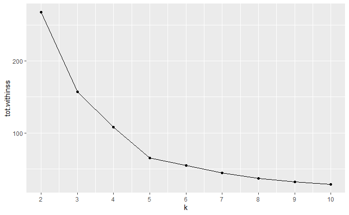

```r
clusterings %>%
  ggplot(aes(x = k,
             y = tot.withinss))+
  geom_point() +
  geom_line()+
  scale_x_continuous(breaks = seq(1, 20, 1))
```

Second plot will be the “silhouette” method, which is similar to a ‘goodness of fit’. The higher the better, and greater than 0.5 is good

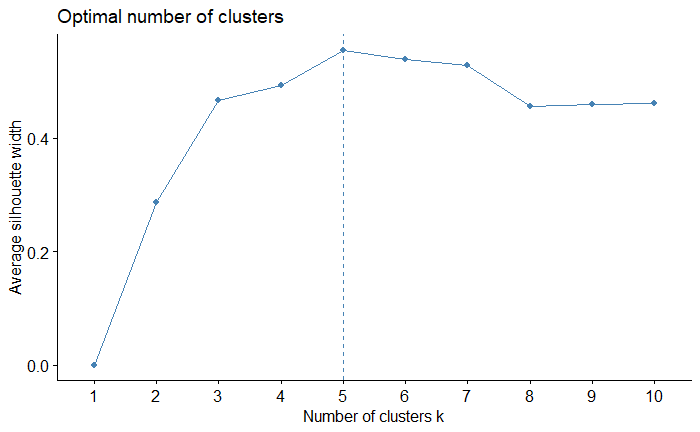

```r
fviz_nbclust(mall_cust_scaled,
             kmeans,
             method = "silhouette",
             nstart = 25)
```

Last method is called gap_stat

```
Clustering k = 1,2,..., K.max (= 10): .. done
Bootstrapping, b = 1,2,..., B (= 100)  [one "." per sample]:
.................................................. 50
.................................................. 100
```

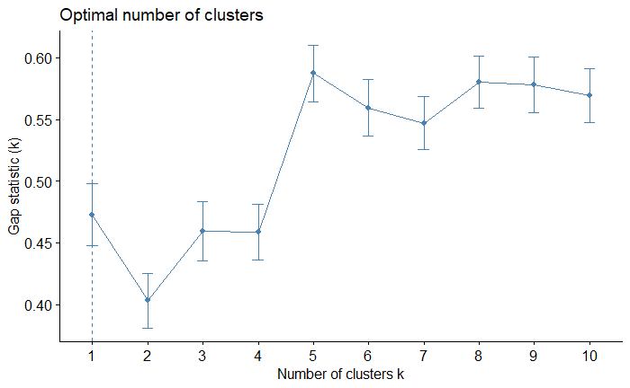

```r
fviz_nbclust(mall_cust_scaled,
             kmeans,
             method = "gap_stat",
             nstart = 25)
```

Elbow method suggests k = 5 Silhouette method suggests k = 5 Gap statistic method suggests k = 1, however the highest value is seen at 5 clusters.

Two of the three methods suggest that 5 is the optimal number of clusters, so will proceed with 5.

# Task 3: Visualise the clustering for your chosen value of k.

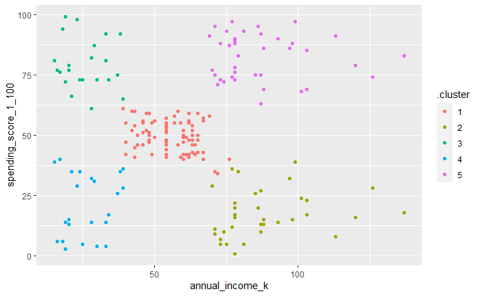

```r
clusterings %>%
  unnest(augmented) %>%
  filter(k == 5) %>%
  ggplot(aes(y = spending_score_1_100, x = annual_income_k,
             colour = .cluster))+
  geom_point()
```

# Task 4: Do you think the clustering seems a good fit for this data?

Yes.Data exploration originally identified 5 groups, which have been assigned in this figure.

# Task 5: Comment on the attributes of one or two of the clusters (maybe even give them an appropriate label if you like - similar to section 4.1 of the ‘Segmentation & clustering intro’ lesson where we saw labels such as “Super Fans” and “Tag-Alongs”).

```r
clusterings %>%
  unnest(augmented) %>%
  filter(k == 5) %>%
  group_by(.cluster) %>%
  summarise(ave_income = mean(annual_income_k),
            ave_age = mean(age),
            ave_spending_score = mean(spending_score_1_100))
```

| .cluster | ave_income | ave_age | ave_spending_score |
| --- | --- | --- | --- |
| 1 | 55.29630 | 42.71605 | 49.51852 |
| 2 | 88.20000 | 41.11429 | 17.11429 |
| 3 | 25.72727 | 25.27273 | 79.36364 |
| 4 | 26.30435 | 45.21739 | 20.91304 |
| 5 | 86.53846 | 32.69231 | 82.12821 |

Could assign group labels dependent on age and earnings

Group 1: >40s / middle earners / middle spenders Group 2: >40s / high earners/ low spenders Group 3: <40s / low earners / high spenders Group 4: >40s / low earners / low spenders Group 5: <40s / high earners / high spenders

Might be worth targetting customers who fit group2 demographics as they have disposable income and don’t spend my in this shop.